# NYPD Shooting Incident Data (Historic)

2/7/2022

## NYPD Shooting Incident Data (Historic)

This is an R Markdown document about NYPD Shooting Incident Data from 2006 to 2020. I accessed data from website: https://catalog.data.gov/dataset and found the dataset titled NYPD Shooting Incident Data (Historic).

### Step 1. Import the shooting project dataset in a reproducible manner

```r
library(tidyverse)
library(lubridate)
url_in <- "https://data.cityofnewyork.us/api/views/833y-fsy8/rows.csv?accessType=DOWNLOAD"
NYPD_shooting_incident <- read_csv(url_in)
summary(NYPD_shooting_incident)
```

```
##   INCIDENT_KEY        OCCUR_DATE         OCCUR_TIME           BORO
##  Min.   :  9953245   Length:23585       Length:23585      Length:23585
##  1st Qu.: 55322804   Class :character   Class1:hms        Class :character
##  Median : 83435362   Mode  :character   Class2:difftime   Mode  :character
##  Mean   :102280741                      Mode  :numeric
##  3rd Qu.:150911774
##  Max.   :230611229
##
##     PRECINCT      JURISDICTION_CODE LOCATION_DESC      STATISTICAL_MURDER_FLAG
##  Min.   :  1.00   Min.   :0.000     Length:23585       Mode :logical
##  1st Qu.: 44.00   1st Qu.:0.000     Class :character   FALSE:19085
##  Median : 69.00   Median :0.000     Mode  :character   TRUE :4500
##  Mean   : 66.21   Mean   :0.333
##  3rd Qu.: 81.00   3rd Qu.:0.000
##  Max.   :123.00   Max.   :2.000
##                   NA's   :2
##  PERP_AGE_GROUP       PERP_SEX          PERP_RACE         VIC_AGE_GROUP
##  Length:23585       Length:23585       Length:23585       Length:23585
##  Class :character   Class :character   Class :character   Class :character
##  Mode  :character   Mode  :character   Mode  :character   Mode  :character
##
##
##
##
##    VIC_SEX            VIC_RACE           X_COORD_CD        Y_COORD_CD
##  Length:23585       Length:23585       Min.   : 914928   Min.   :125757
##  Class :character   Class :character   1st Qu.: 999925   1st Qu.:182539
##  Mode  :character   Mode  :character   Median :1007654   Median :193470
##                                        Mean   :1009379   Mean   :207300
##                                        3rd Qu.:1016782   3rd Qu.:239163
##                                        Max.   :1066815   Max.   :271128
##
##     Latitude       Longitude        Lon_Lat
##  Min.   :40.51   Min.   :-74.25   Length:23585
##  1st Qu.:40.67   1st Qu.:-73.94   Class :character
##  Median :40.70   Median :-73.92   Mode  :character
##  Mean   :40.74   Mean   :-73.91
##  3rd Qu.:40.82   3rd Qu.:-73.88
##  Max.   :40.91   Max.   :-73.70
##
```

### Step 2. Tidy and transform data

1.Getting rid of the columns I do not need for analysis.

2.Changing appropriate variables to factor and date types.

3.Add a new column which is named year, which count shooting incidents by year,I will use this data for my further study.

```r
shooting_historic <- NYPD_shooting_incident %>%
                     select(-c(PRECINCT,JURISDICTION_CODE,X_COORD_CD,Y_COORD_CD,
                            LOCATION_DESC,Latitude,Longitude,Lon_Lat))%>%
                     mutate(BORO=factor(BORO),STATISTICAL_MURDER_FLAG=factor(STATISTICAL_MURDER_FLAG),
                     PERP_AGE_GROUP=factor(PERP_AGE_GROUP),PERP_RACE=factor(PERP_RACE),
                     PERP_SEX=factor(PERP_SEX),VIC_AGE_GROUP=factor(VIC_AGE_GROUP),
                     VIC_SEX=factor(VIC_SEX), VIC_RACE=factor(VIC_RACE),
                     OCCUR_DATE=mdy(OCCUR_DATE),OCCUR_TIME=hms(OCCUR_TIME), YEAR=year(OCCUR_DATE))
summary(shooting_historic)
```

```
##   INCIDENT_KEY         OCCUR_DATE           OCCUR_TIME
##  Min.   :  9953245   Min.   :2006-01-01   Min.   :0S
##  1st Qu.: 55322804   1st Qu.:2008-12-31   1st Qu.:3H 20M 0S
##  Median : 83435362   Median :2012-02-27   Median :15H 0M 0S
##  Mean   :102280741   Mean   :2012-10-05   Mean   :12H 33M 7.48187407250225S
##  3rd Qu.:150911774   3rd Qu.:2016-03-02   3rd Qu.:20H 45M 0S
##  Max.   :230611229   Max.   :2020-12-31   Max.   :23H 59M 0S
##
##             BORO      STATISTICAL_MURDER_FLAG PERP_AGE_GROUP PERP_SEX
##  BRONX        :6701   FALSE:19085             18-24  :5508   F   :  335
##  BROOKLYN     :9734   TRUE : 4500             25-44  :4714   M   :13490
##  MANHATTAN    :2922                           UNKNOWN:3148   U   : 1499
##  QUEENS       :3532                           <18    :1368   NA's: 8261
##  STATEN ISLAND: 696                           45-64  : 495
##                                               (Other):  57
##                                               NA's   :8295
##           PERP_RACE     VIC_AGE_GROUP   VIC_SEX
##  BLACK         :10025   <18    : 2525   F: 2204
##  WHITE HISPANIC: 1988   18-24  : 9003   M:21370
##  UNKNOWN       : 1836   25-44  :10303   U:   11
##  BLACK HISPANIC: 1096   45-64  : 1541
##  WHITE         :  255   65+    :  154
##  (Other)       :  124   UNKNOWN:   59
##  NA's          : 8261
##                            VIC_RACE          YEAR
##  AMERICAN INDIAN/ALASKAN NATIVE:    9   Min.   :2006
##  ASIAN / PACIFIC ISLANDER      :  327   1st Qu.:2008
##  BLACK                         :16869   Median :2012
##  BLACK HISPANIC                : 2245   Mean   :2012
##  UNKNOWN                       :   65   3rd Qu.:2016
##  WHITE                         :  620   Max.   :2020
##  WHITE HISPANIC                : 3450
```

```r
shooting_historic$PERP_AGE_GROUP[is.na(shooting_historic$PERP_AGE_GROUP)] = "UNKNOWN"
shooting_historic$PERP_SEX[is.na(shooting_historic$PERP_SEX)] = "U"
shooting_historic$PERP_AGE_GROUP[is.na(shooting_historic$PERP_AGE_GROUP)] = "UNKNOWN"
summary(shooting_historic)
```

```
##   INCIDENT_KEY         OCCUR_DATE           OCCUR_TIME
##  Min.   :  9953245   Min.   :2006-01-01   Min.   :0S
##  1st Qu.: 55322804   1st Qu.:2008-12-31   1st Qu.:3H 20M 0S
##  Median : 83435362   Median :2012-02-27   Median :15H 0M 0S
##  Mean   :102280741   Mean   :2012-10-05   Mean   :12H 33M 7.48187407250225S
##  3rd Qu.:150911774   3rd Qu.:2016-03-02   3rd Qu.:20H 45M 0S
##  Max.   :230611229   Max.   :2020-12-31   Max.   :23H 59M 0S
##
##             BORO      STATISTICAL_MURDER_FLAG PERP_AGE_GROUP  PERP_SEX
##  BRONX        :6701   FALSE:19085             UNKNOWN:11443   F:  335
##  BROOKLYN     :9734   TRUE : 4500             18-24  : 5508   M:13490
##  MANHATTAN    :2922                           25-44  : 4714   U: 9760
##  QUEENS       :3532                           <18    : 1368
##  STATEN ISLAND: 696                           45-64  :  495
##                                               65+    :   54
##                                               (Other):    3
##           PERP_RACE     VIC_AGE_GROUP   VIC_SEX
##  BLACK         :10025   <18    : 2525   F: 2204
##  WHITE HISPANIC: 1988   18-24  : 9003   M:21370
##  UNKNOWN       : 1836   25-44  :10303   U:   11
##  BLACK HISPANIC: 1096   45-64  : 1541
##  WHITE         :  255   65+    :  154
##  (Other)       :  124   UNKNOWN:   59
##  NA's          : 8261
##                            VIC_RACE          YEAR
##  AMERICAN INDIAN/ALASKAN NATIVE:    9   Min.   :2006
##  ASIAN / PACIFIC ISLANDER      :  327   1st Qu.:2008
##  BLACK                         :16869   Median :2012
##  BLACK HISPANIC                : 2245   Mean   :2012
##  UNKNOWN                       :   65   3rd Qu.:2016
##  WHITE                         :  620   Max.   :2020
##  WHITE HISPANIC                : 3450
```

### Step 3. Add visualizations and analysis

1.Total count of shooting incidents by year.

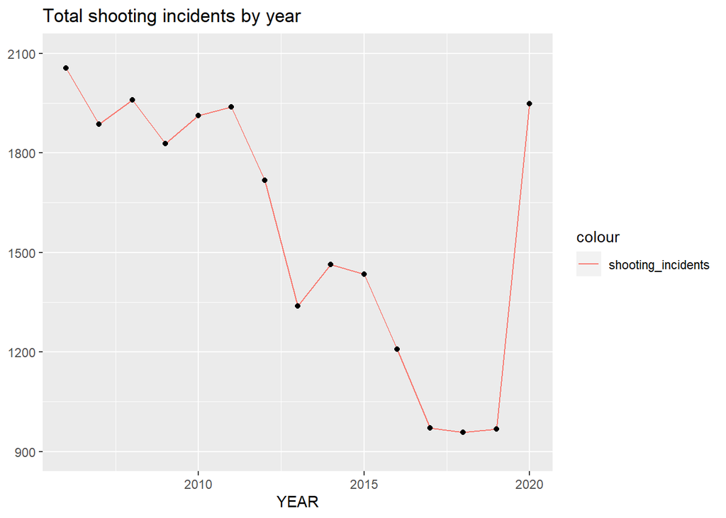

```r
total_count_by_year <- shooting_historic %>% group_by(YEAR)%>%summarize(shooting_incidents=n())
total_count_by_year%>%
  ggplot(aes(x=YEAR,y=shooting_incidents))+geom_line(aes(color="shooting_incidents"))+
  coord_cartesian(xlim=c(2006,2020),ylim=c(900,2100))+geom_point()+
  labs(title=str_c("Total shooting incidents by year"),y=NULL)
```

2.Distribution of shooting incidents in each borough by year.

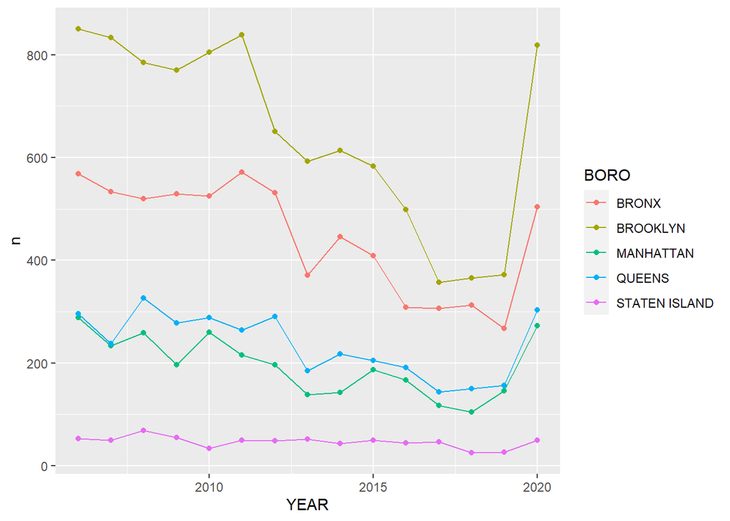

```r
total_count_by_year_boro <- shooting_historic %>% count(YEAR, BORO)
total_count_by_year_boro%>%
ggplot(aes(x=YEAR, y=n, colour=BORO)) + geom_line() + geom_point()
```

According to this visualization, Brooklyn has the overall highest number of shooting incidents, and Staten island has the lowest number.

3.Victims by gender and age group and race.

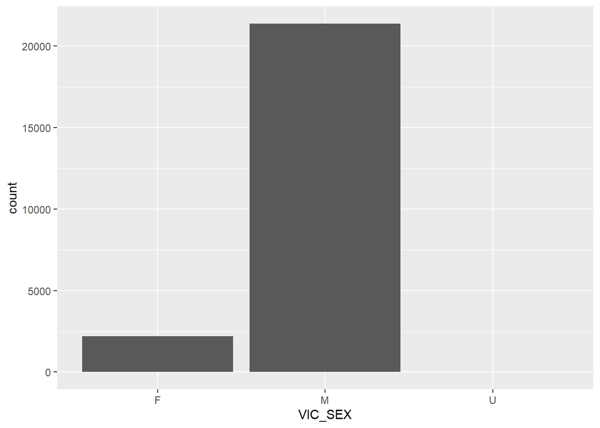

```r
ggplot(data = shooting_historic) +geom_bar(aes(x = VIC_SEX))
```